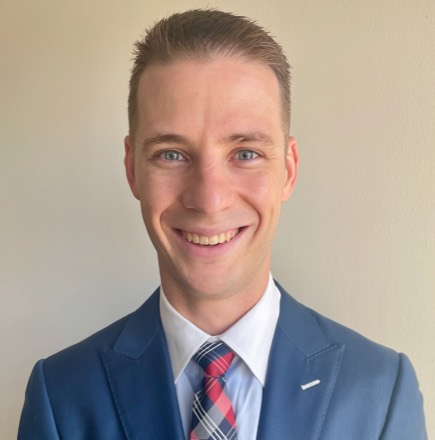

MAJ, U.S. Army · Operations Research / Systems Analysis

# Austin Semmel

Instructor, Department of Mathematical Sciences

United States Military Academy, West Point

Modeler · Ultrarunner · Army Officer · Dad

austinsemmel.com Email [GitHub](https://github.com/defense031) [The Forge](https://shiny.austinsemmel.com)

## About

I teach probability, statistics, and mathematical modeling to cadets at West Point, and I build interactive apps that let them turn the knobs on a concept instead of reading about it. My research is on how the Army flies and maintains its aircraft: what readiness numbers actually measure, how units decide to launch, and when a maintenance technology stops paying for itself.

Before teaching I spent a decade in Army finance and operations research, resourcing units from a military police brigade in the Indo-Pacific to a three-star special operations headquarters. I hold a PhD in Operations Research from NC State, along with master's degrees in statistics and operations research, and a BS in Economics from West Point.

## Research

Dissertation — NC State, 2026

[The Readiness–Utilization Trade Space in U.S. Army Aviation](https://www.lib.ncsu.edu/resolver/1840.20/46639)

Uses daily AH-64 Apache operational data to treat readiness and utilization as joint outcomes of one coupled system, characterizing how units make flying decisions and where predictive maintenance stops returning value.

Publication

Evaluating the implementation of operational readiness and maintenance policies in US Army aviation

Semmel AD, Heese HS, McConnell BM. *Journal of Defense Modeling and Simulation*, 2025. [doi:10.1177/15485129251328044](https://doi.org/10.1177/15485129251328044)

Software — CRAN

grassr: context-conditioned reporting for binary rater reliability, with Rachel Gidaro.

Places each agreement coefficient on a reference surface calibrated to the study's rater count, sample size, and prevalence. [Docs](https://defense031.github.io/grassr/) · [Source](https://github.com/defense031/grassr)

## Selected Presentations

- Predictive Maintenance Under Prognostic Uncertainty: The Marginal Value of RUL Accuracy in Fleet Operations 94th MORS Symposium, June 2026 · Working Group 17, Logistics, Reliability and Maintainability
- A Framework for Analyzing Operational Efficiency in US Army Aviation: Self-Organizing Map-based Clustering of Flight Dispatch Decisions 93rd MORS Symposium, June 2025 Best in Working Group: Readiness
- Tradeoffs in Army Aviation Training and Maintenance INFORMS Annual Meeting, October 2023 · 61st Army Operations Research Symposium, September 2023

## Teaching

MA103

Mathematical Modeling and Introduction to Calculus. Data analytics, classification, optimization, and continuous and discrete functions.

MA206

Probability and Statistics. Probability, distributions, inference, and regression.

MA376

Applied Statistics. Hypothesis testing, ANOVA, categorical data, regression, and nonparametric methods.

Cadet Research

NORAD data visualization, LLMs for tabular query, continuous glucose monitoring, aircraft mission scheduling, and computer vision explainability.

## Code & Apps

THE FORGE is a set of interactive Shiny apps for statistics and modeling concepts. Each one ends in **The Anvil**, a sandbox built for breaking things.

Hypothesis Testing

[One- and two-sample inference](https://shiny.austinsemmel.com/HypothesisTesting/) with theoretical and simulation-based methods.

Permutation Test Explorer

[Build the null distribution](https://shiny.austinsemmel.com/PermutationTest/) by shuffling labels, then find the small skewed samples where the t-test disagrees.

Bias–Variance Tradeoff

[Polynomial fitting](https://shiny.austinsemmel.com/BiasVariance/), KNN regression, and the decomposition itself.

All Apps

The full collection lives at shiny.austinsemmel.com.

The Blueprint

##### The Question

A helicopter fleet is asked to do two things that fight each other. Fly it hard and it earns the training hours the unit is graded on. Fly it hard and parts wear out, so the readiness rate the unit is *also* graded on falls. The Army manages this with one headline number, the mission-capable rate, and that number cannot tell a fleet that is healthy from a fleet that is idle.

##### The Model

Readiness and utilization come out of one coupled system, so I model them jointly rather than optimizing either alone. On any given day a unit's dispatch decision balances the flight hours it gains against the expected maintenance it incurs:

\[ \max_{u_t} \; \sum_{t=1}^{T} \big[\, v(u_t) - c\big(E[D_{t+1} \mid u_t]\big) \,\big] \]

where \(u_t\) is aircraft flown on day \(t\), \(v(\cdot)\) the training value earned, and \(D_{t+1}\) the downtime that flying induces tomorrow. The interesting behavior lives in that lag: today's value is certain, tomorrow's cost is not.

##### Prognostics

Predictive maintenance promises to forecast remaining useful life and schedule the repair before the failure. Its payoff depends on how accurate that forecast is, and accuracy is expensive. Past a point, buying more of it changes nothing a commander would do differently.

##### The Teaching Connection

Every Forge app grew out of the same habit this research runs on: if you cannot move the input and watch the answer respond, you do not yet understand the model.